# Module 5 worksheet

```r
library(ggplot2) #load ggplot
library(ggthemes) #load themes package for ggplot
theme_set(theme_tufte()) # a theme I like.

#set some options that I like
theme_update(plot.title = element_text(hjust = 0.5),
             axis.line.x = element_line(color="black", size = 1),
             axis.line.y = element_line(color="black", size = 1),
             text=element_text(size=20),
             axis.text=element_text(size=15)) #center all titles and and axis lines
```

# Exercise 5A

## Calculating and plotting correlations

Load the dataset `ColCountsFinal.csv`. This dataset is the counts of beaver colonies of different populations throughout Northern Minnesota (Johnson-Bice et al. 2020). Ecologists are often interested in the degree of synchrony in populations over space.

1. Cacluate the correlations between populations.
2. Use the `corrplot` library to plot these correlations.

```r
library(corrplot)
beav.dat <- read.csv(file="../Data/BeaverDensities.csv")
M <- cor(beav.dat[,-1], use="pairwise.complete") #extract numeric responses
corrplot.mixed(M)

corr.vec <- M[lower.tri(M)]
```

[output not shown]

# Exercise 5B

## Simple linear regression

Now load a datast that has these correlations and the distances between each population (`CorrDistance.csv`). Test to see whether correlation between populations varies by distance in a predictable manner. What information from the regression did you use to draw your conclusions?

```r
confint(lm(correlation ~ distance, data=corr.dat))
```

```
                    2.5 %       97.5 %
(Intercept)  1.055345e-01 3.935648e-01
distance    -3.918658e-07 9.874464e-07
```

### The confidence interval of the distance effect shows that our estimate is consistent with zero, thus there is no evidence of a relationship between distance and correlation.

The data set contained in `LionNoses.csv` contains the age of male lions and the proportion of their nose that is black (from Whitman et al. 2004). The proportional amount of black on a lions nose tends to change as an individual ages, a pattern that can be used to identify individual lions (http://livingwithlions.org/mara/how-to/identify-lions/).

Load this dataset and create a linear model to relate the proportion blackness in a lions nose to it’s age. Interpret the slope, intercept, any significance tests, and the $R^2$ value.

```r
summary(lm(ageInYears ~ proportionBlack, data=lion.dat))
```

```
Call:
lm(formula = ageInYears ~ proportionBlack, data = lion.dat)

Residuals:
    Min      1Q  Median      3Q     Max
-2.5449 -1.1117 -0.5285  0.9635  4.3421

Coefficients:
                Estimate Std. Error t value Pr(>|t|)
(Intercept)       0.8790     0.5688   1.545    0.133
proportionBlack  10.6471     1.5095   7.053 7.68e-08 ***
---
Signif. codes:  0 ‘***’ 0.001 ‘**’ 0.01 ‘*’ 0.05 ‘.’ 0.1 ‘ ’ 1

Residual standard error: 1.669 on 30 degrees of freedom
Multiple R-squared:  0.6238,    Adjusted R-squared:  0.6113
F-statistic: 49.75 on 1 and 30 DF,  p-value: 7.677e-08
```

### The slope value is 10.6 indicating that for a unit increase in the proportion black of the nose the lion is 10 years older. The p-value of this estimate indicates that the estimate statististical differs from 0 and the $R^2$ value indicates that hte model explains over 60% of the variation in the data.

# Exercise 5C

## Multiple linear regression

1. Read in the dataset, `monet.csv`. Build a model that includes the effects of HOUSE (the auction house), SIGNED (whether the painting was signed), HEIGHT and WIDTH.

```r
monet.dat       <- read.csv(file="../Data/monet.csv", header=TRUE)
monet.dat$HOUSE <- as.factor(monet.dat$HOUSE)
monet.dat$SIGNED <- as.factor(monet.dat$SIGNED)
monet.dat <- subset(monet.dat, SIZE< 2000) #just take the paintings less that size 2000 cm^2

monet.mod <- lm(PRICE ~ HEIGHT + WIDTH + SIGNED + HOUSE -1 , data=monet.dat)
summary(monet.mod)
```

```
Call:
lm(formula = PRICE ~ HEIGHT + WIDTH + SIGNED + HOUSE - 1, data = monet.dat)

Residuals:
    Min      1Q  Median      3Q     Max
-5.3409 -2.1425 -1.0690  0.6608 27.4847

Coefficients:
        Estimate Std. Error t value Pr(>|t|)
HEIGHT   0.13133    0.02559   5.133 4.42e-07 ***
WIDTH    0.11236    0.03036   3.701 0.000244 ***
SIGNED0 -6.06374    1.12442  -5.393 1.18e-07 ***
SIGNED1 -3.91213    1.06250  -3.682 0.000263 ***
HOUSE2   0.41754    0.40187   1.039 0.299429
HOUSE3   0.57114    0.90944   0.628 0.530351
---
Signif. codes:  0 ‘***’ 0.001 ‘**’ 0.01 ‘*’ 0.05 ‘.’ 0.1 ‘ ’ 1

Residual standard error: 3.904 on 407 degrees of freedom
Multiple R-squared:  0.4324,    Adjusted R-squared:  0.4241
F-statistic: 51.69 on 6 and 407 DF,  p-value: < 2.2e-16
```

Based on your model does a centimeter increase in WIDTH or HEIGHT differently affect the PRICE? Does having a signed painting increase it’s value? Use the `sjPlot` library to plot PRICE predictions against HEIGHT for both signed and unsigned paintings.

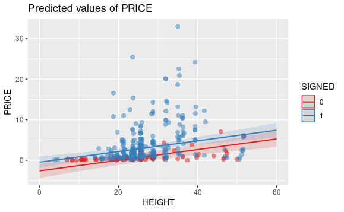

### The model estimates indicate that an increase in height has a slightly larger increase on price than width but they do appear similar. have about the same effect. We also see that signed paintings are more valuable than unsigned paintings.

# Exercise 5D

## Run an ANOVA model

Run an ANOVA on the model you defined above and a similar model without the signature. How do you interpret differences in the F-tests on HOUSE in both of these models?

```r
summary(aov(monet.mod2))
```

[output not shown]